# Project 2: Data Mining, Classification, Prediction

SDS322E

# Mining, Classification, Prediction

## Sarah Isaack sji259

### Introduction

The dataset I will be using joins two separate datasets both about different aspects of Halloween candy. The first original dataset came from an article regarding each of the 50 U.S. states’ favorite Halloween candy and focuses on which candy is each state’s favorite as well as the number of pounds purchased by each state. The second original dataset came from the fivethirtyeight library already available on R and focuses on the flavors present in each listed candy as well as their sugar percentiles, price percentiles, and how often the candy won a popularity poll when pitted against the other candies. In the joined dataset, there are 51 observations for each U.S. state including Washington D.C. and 15 different variables. There are first binary variables for flavor which show if the candy has a chocolate, fruity, caramel, peanuty/almondy, nougat, or crisped rice wafer flavor, or a combination of these. Then, there is the hard variable which describes the candy’s texture. Next, the bar variable explains if the candy comes in a bar shape, and pluribus explains if the candy is one of multiple in the package or if it stands alone. The sugarpercent and pricepercent variables show the percentile of sugar and price respectively compared to the rest of the candies, and the winpercent shows how often the candy won in the 269,000 matchups performed. Lastly, state is the state where the candy type is the most popular and pounds is how many pounds of candy were bought by the previously mentioned state.

```r
library(tidyverse)
library(readr)
state_candy <- read_csv("/stor/home/sji259/project1/state_candy.csv")
library(fivethirtyeight)
candy_rankings <- candy_rankings
joined_candy <- right_join(candy_rankings, state_candy, by = c(competitorname = "Top Candy"))
```

### Cluster Analysis

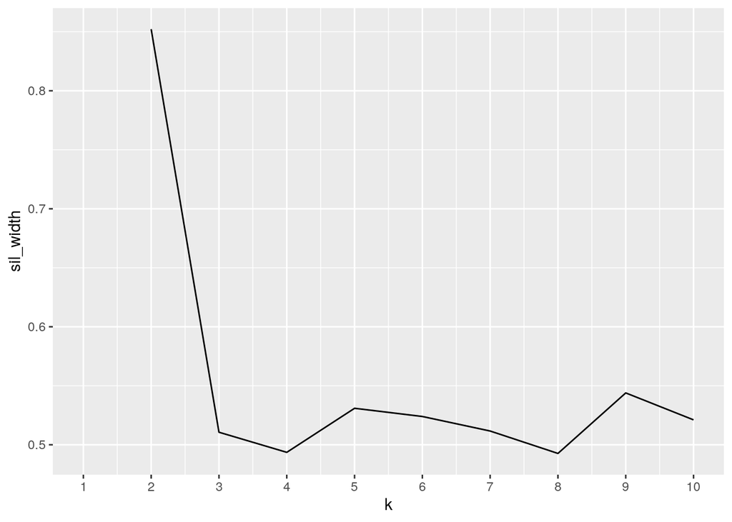

```r
library(cluster)
library(GGally)
pam_dat <- joined_candy %>% select(sugarpercent, pricepercent,
    winpercent, Pounds)
sil_width <- vector()
for (i in 2:10) {
    pam_fit <- pam(pam_dat, k = i)
    sil_width[i] <- pam_fit$silinfo$avg.width
}
ggplot() + geom_line(aes(x = 1:10, y = sil_width)) + scale_x_continuous(name = "k",
    breaks = 1:10)
```

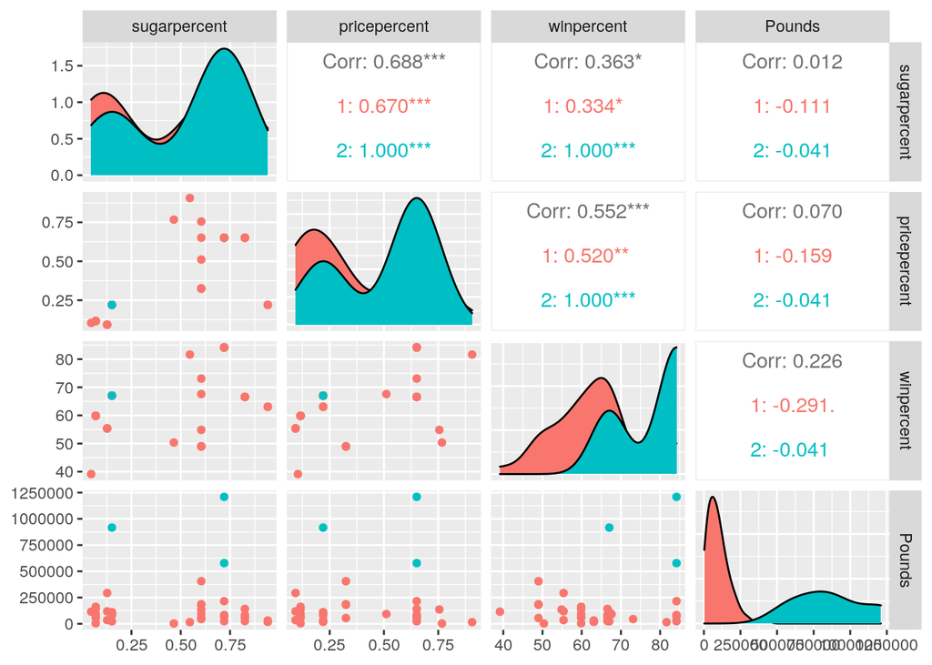

```r
pam_candy <- pam_dat %>% pam(k = 2)
candy_clust <- pam_dat %>% mutate(cluster = as.factor(pam_candy$clustering))
ggpairs(candy_clust, columns = 1:4, aes(color = cluster))
```

```r
pam_candy$silinfo$avg.width
```

```
## [1] 0.8522121
```

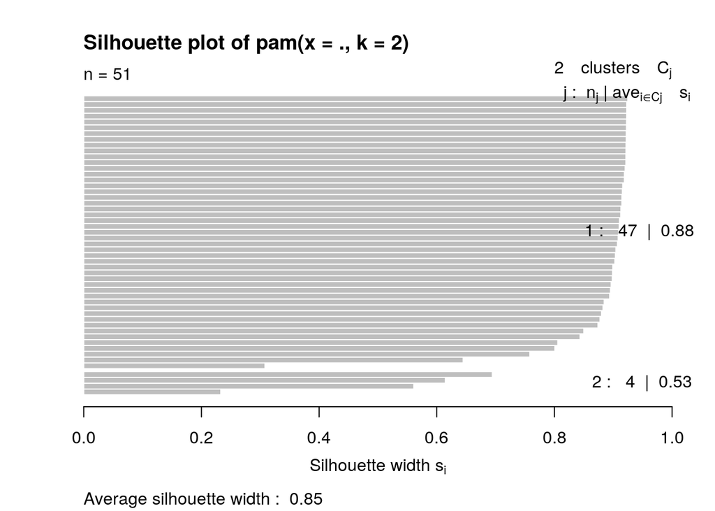

```r
plot(pam_candy, which = 2)
```

### Dimensionality Reduction with PCA

```r
pca_dat <- joined_candy %>% select_if(is.numeric) %>% scale %>%
    na.omit
pca_candy <- princomp(pca_dat)
summary(pca_candy, loadings = T)
```

```
## Importance of components:
##                           Comp.1    Comp.2    Comp.3     Comp.4
## Standard deviation     1.4339936 1.0466271 0.7570448 0.51318373
## Proportion of Variance 0.5156003 0.2746645 0.1437017 0.06603352
## Cumulative Proportion  0.5156003 0.7902648 0.9339665 1.00000000
##
## Loadings:
##              Comp.1 Comp.2 Comp.3 Comp.4
## sugarpercent  0.557  0.281  0.535  0.570
## pricepercent  0.618  0.168        -0.763
## winpercent    0.526 -0.190 -0.772  0.303
## Pounds        0.174 -0.926  0.335
```

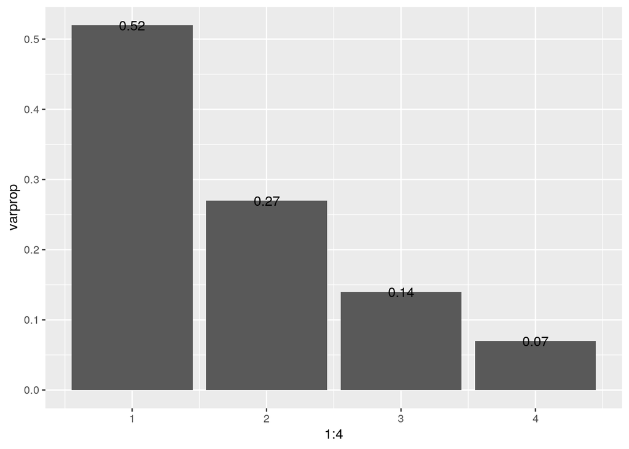

```r
eigval <- pca_candy$sdev^2
varprop = round(eigval/sum(eigval), 2)
ggplot() + geom_bar(aes(y = varprop, x = 1:4), stat = "identity") +
    geom_text(aes(x = 1:4, y = varprop, label = round(varprop,
        2)))
```

Before performing my PCA, I first scaled the data, and had to omit some NAs that were present in my dataset. Then, I used the princomp function to perform the PCA and created a ggplot to analyze the proportion of total variance that each principal component explained. This plot showed that PCs 1-4 accounted for 100% of the variance in the data, so I will be using all four. After analyzing all four PCs, some relationships were established. The analysis showed that if a candy scores highly on PC 1, then their sugar percentile, price percentile, win percentage, and amount purchased in pounds will be higher and would be lower if the candy scored poorly on PC 1. If a candy scores highly on PC 2, then sugar percentile and price percentile will be slightly higher, win percentage will be slightly lower, and the amount purchased in pounds will be significantly lower, and vice versa if PC 2 is scored lowly on. If a candy scores highly on PC 3, then its sugar percentile and amount purchased in pounds will increase, however its win percentage will decrease, which again would become the opposite if PC 3 is scored lowly on. Lastly, if a candy scores highly on PC 4, then its sugar percentile and win percentage will increase while its price percentile decreases, and again vice versa for in the candy scored lowly on PC 4.

### Linear Classifier

```r
glm_data <- joined_candy %>% na.omit
logistic_fit <- glm(chocolate == "TRUE" ~ sugarpercent + pricepercent +
    winpercent + Pounds, data = glm_data, family = "binomial")

prob_candy <- predict(logistic_fit)
score <- predict(logistic_fit, type = "response")
score %>% round(3)
```

```
##     1     2     3     4     5     6     7     8     9    10    11    12    13
## 0.802 0.986 0.172 0.158 0.203 0.353 0.937 0.937 0.942 0.939 0.935 0.896 0.951
##    14    15    16    17    18    19    20    21    22    23    24    25    26
## 0.903 0.858 0.836 0.838 0.829 0.365 0.365 0.368 0.140 0.164 0.148 0.149 0.153
##    27    28    29    30    31    32    33    34    35    36    37    38    39
## 0.160 0.230 0.224 0.226 0.230 0.212 0.436 0.985 0.744 0.715 0.791 0.745 0.975
```

```r
y <- glm_data$chocolate
y_hat <- ifelse(score > 0.5, "TRUE", "FALSE")
table(actual = y, predicted = y_hat) %>% addmargins
```

```
##        predicted
## actual  FALSE TRUE Sum
##   FALSE    16    1  17
##   TRUE      3   19  22
##   Sum      19   20  39
```

```r
class_diag(prob_candy, glm_data$chocolate, positive = "TRUE")
```

```
##            acc   sens   spec  ppv     f1     ba    auc
## Metrics 0.8974 0.8636 0.9412 0.95 0.9048 0.9024 0.8583
```

```r
set.seed(1234)
k = 5
data <- sample_frac(glm_data)
folds <- rep(1:k, length.out = nrow(data))

diags <- NULL

i = 1
for (i in 1:k) {
    train <- data[folds != i, ]
    test <- data[folds == i, ]
    truth <- test$chocolate


    fit <- glm(chocolate == "TRUE" ~ sugarpercent + pricepercent +
        winpercent + Pounds, data = train, family = "binomial")
    probs <- predict(fit, newdata = test, type = "response")

    diags <- rbind(diags, class_diag(probs, truth, positive = "TRUE"))
}
summarize_all(diags, mean)
```

```
##       acc    sens spec    ppv   f1      ba     auc
## 1 0.81786 0.82668 0.75 0.8362 0.82 0.78832 0.72668
```

I decided to use logistic regression to analyze my data. The first step was to remove some NAs in my data that would have not allowed the glm to run. Next, I created the logistic fit and used it to predict the identities of each candy for whether or not they included chocolate based on the four numeric variables, sugar percentile, price percentile, win percentage, and pounds purchased. I then created a confusion matrix seen above which shows that there are 19 true positives, 1 false positive, 16 true negatives, and 3 false negatives. Lastly, the class diag function was used to analyze aspects of this logistic regression model. This function showed that the accuracy was 0.8974, or that 89.74% of candies were classified correctly. It showed that the sensitivity was 0.8636, or that 86.36% of candies with chocolate were classified correctly. The specificity was found to be 0.9412, or 94.12% of the candies without chocolate were classified correctly. The precision was found to be 0.95, or 95% of candies that were predicted to have chocolate did have chocolate. Lastly, the AUC was found to be 0.8583 which means this model is doing a pretty good job at predicting the data.

After analyzing the logistic regression model, I performed a cross validation on my data. Using 5 folds due to a smaller dataset, I got an AUC of 0.72668, which is lower than the AUC was for the logistic regression. Because the AUC decreased by about 0.14, I would say this data does show signs of overfitting, even if the cross validated predictor is performing fairly well. During this cross-validation it was also observed that the accuracy, sensitivity, specificity, and precision decreased alongside the AUC as well.

### Non-Parametric Classifier

```r
library(caret)
knn_fit_candy <- knn3(factor(chocolate == "TRUE", levels = c("TRUE",
    "FALSE")) ~ sugarpercent + pricepercent + winpercent + Pounds,
    data = glm_data, k = 5)
y_hat_candy <- predict(knn_fit_candy, glm_data)
class_diag(y_hat_candy[, 1], glm_data$chocolate, positive = "TRUE")
```

```
##           acc   sens   spec    ppv     f1     ba    auc
## Metrics 0.641 0.7273 0.5294 0.6667 0.6957 0.6283 0.7072
```

```r
table(actual = y, predicted = factor(y_hat_candy[, 1] > 0.5,
    levels = c("TRUE", "FALSE"))) %>% addmargins
```

```
##        predicted
## actual  TRUE FALSE Sum
##   FALSE    8     9  17
##   TRUE    16     6  22
##   Sum     24    15  39
```

```r
glm_data2 <- glm_data %>% mutate(chocolate = ifelse(chocolate ==
    "TRUE", 1, 0))
set.seed(1234)
cv <- trainControl(method = "cv", number = 5, classProbs = T,
    savePredictions = T)
fit <- train(chocolate ~ sugarpercent + pricepercent + winpercent +
    Pounds, data = glm_data2, trControl = cv, method = "knn")
class_diag(fit$pred$pred, fit$pred$obs, positive = 1)
```

```
##            acc   sens   spec    ppv     f1     ba    auc
## Metrics 0.5556 0.6515 0.4314 0.5972 0.6232 0.5414 0.5097
```

I chose to use k nearest neighbors to perform a non-parametirc classification. I first used all of the data to predict whether each specific candy contained chocolate as a flavor using this KNN method. After predicting the fit and using the class diag function, the AUC was found to be 0.7072, which is lower than the AUC was for the linear regression model used before, and it means this model is doing a fair job at predicting the identity of each candy in regards to chocolate. When a confusion matrix was made, it was found that there were 16 true positives, 8 false positives, 9 true negatives, and 6 false negatives.

### Regression/Numeric Prediction

```r
candy_fit <- lm(Pounds ~ competitorname + State, data = glm_data)
candy_yhat <- predict(candy_fit)

mean((glm_data$Pounds - candy_yhat)^2)
```

```
## [1] 1.091726e-19
```

```r
set.seed(1234)
cv <- trainControl(method = "cv", number = 5, classProbs = T,
    savePredictions = T)
fit <- train(Pounds ~ competitorname + State, data = glm_data2,
    trControl = cv, method = "rpart")
min(fit$results$RMSE)^2
```

```
## [1] 47747466068
```

### Python

```r
library(reticulate)
```

```python
candy_data=r.glm_data
sum(candy_data['chocolate'])/len(candy_data['chocolate'])
```

```
## 0.5641025641025641
```

```python
propchoc=0.5641025641025641
```

```r
py$propchoc
```

```
## [1] 0.5641026
```

In python I found the proportion of all candies that hada chocolate flavor by taking the sum of all “true” chocolate candies and dividin it by all listed candies. I then assigned this value to “propchoc” in python and was able to retrieve it in r by using reticulate which allows the interplay between r and python.